# Job_Change_Analysis_of_Data_Scientists

Manisha Rana

2022-12-27

## Project Objective

### A company which is active in Big Data and Data Science offers trainings to people and they want to assess the potential of hiring Data Scientists from this pool of people who successfully pass some of the courses that the company offers. Information related to demographics, education, experience and other details are collected from people when they enroll for the trainings. Based on these factors company wants to understand which people can consider joining them as Data Scientists. Target variable is the probability of a candidate to either look for a job change or not. The training set contains the target variable along with other variables and the test set does not contain the target variable.

### Importing the libraries

```r
library(dplyr)
```

```r
library(ggplot2)
library(car)
library(GGally)
library(fastDummies)
library(caret)
library(DescTools)
library(rpart)
library(randomForest)
library(rpart)
library(e1071)
library(rattle)
library(VIM)
library(mice)
```

### Loading the train and test csv files. The dataset has been downloaded from Kaggle

```r
associate_train_df <- read.csv("aug_train.csv",header=TRUE,sep=",")
associate_test_df <- read.csv("aug_test.csv",header=TRUE,sep=",")
```

### Checking the structure of the data

```r
str(associate_train_df)
```

```
## 'data.frame':    19158 obs. of  14 variables:
##  $ enrollee_id           : int  8949 29725 11561 33241 666 21651 28806 402 27107 699 ...
##  $ city                  : chr  "city_103" "city_40" "city_21" "city_115" ...
##  $ city_development_index: num  0.92 0.776 0.624 0.789 0.767 0.764 0.92 0.762 0.92 0.92 ...
##  $ gender                : chr  "Male" "Male" "" "" ...
##  $ relevent_experience   : chr  "Has relevent experience" "No relevent experience" "No relevent experience" "No relevent experience" ...
##  $ enrolled_university   : chr  "no_enrollment" "no_enrollment" "Full time course" "" ...
##  $ education_level       : chr  "Graduate" "Graduate" "Graduate" "Graduate" ...
##  $ major_discipline      : chr  "STEM" "STEM" "STEM" "Business Degree" ...
##  $ experience            : chr  ">20" "15" "5" "<1" ...
##  $ company_size          : chr  "" "50-99" "" "" ...
##  $ company_type          : chr  "" "Pvt Ltd" "" "Pvt Ltd" ...
##  $ last_new_job          : chr  "1" ">4" "never" "never" ...
##  $ training_hours        : int  36 47 83 52 8 24 24 18 46 123 ...
##  $ target                : num  1 0 0 1 0 1 0 1 1 0 ...
```

```r
str(associate_test_df)
```

```
## 'data.frame':    2129 obs. of  13 variables:
##  $ enrollee_id           : int  32403 9858 31806 27385 27724 217 21465 27302 12994 16287 ...
##  $ city                  : chr  "city_41" "city_103" "city_21" "city_13" ...
##  $ city_development_index: num  0.827 0.92 0.624 0.827 0.92 0.899 0.624 0.92 0.878 0.624 ...
##  $ gender                : chr  "Male" "Female" "Male" "Male" ...
##  $ relevent_experience   : chr  "Has relevent experience" "Has relevent experience" "No relevent experience" "Has relevent experience" ...
##  $ enrolled_university   : chr  "Full time course" "no_enrollment" "no_enrollment" "no_enrollment" ...
##  $ education_level       : chr  "Graduate" "Graduate" "High School" "Masters" ...
##  $ major_discipline      : chr  "STEM" "STEM" "" "STEM" ...
##  $ experience            : chr  "9" "5" "<1" "11" ...
##  $ company_size          : chr  "<10" "" "" "10/49" ...
##  $ company_type          : chr  "" "Pvt Ltd" "Pvt Ltd" "Pvt Ltd" ...
##  $ last_new_job          : chr  "1" "1" "never" "1" ...
##  $ training_hours        : int  21 98 15 39 72 12 11 81 2 4 ...
```

### the train dataset has 19158 observations and 14 variables. The test dataset has 2129 observations and 13 variables

### Checking for missing data in the dataset and converting empty cells to NA

```r
associate_train_df[associate_train_df==""] <- NA
colSums(is.na(associate_train_df))
```

```
##            enrollee_id                   city city_development_index
##                      0                      0                      0
##                 gender    relevent_experience    enrolled_university
##                   4508                      0                    386
##        education_level       major_discipline             experience
##                    460                   2813                     65
##           company_size           company_type           last_new_job
##                   5938                   6140                    423
##         training_hours                 target
##                      0                      0
```

```r
associate_test_df[associate_test_df==""] <- NA
colSums(is.na(associate_test_df))
```

```
##            enrollee_id                   city city_development_index
##                      0                      0                      0
##                 gender    relevent_experience    enrolled_university
##                    508                      0                     31
##        education_level       major_discipline             experience
##                     52                    312                      5
##           company_size           company_type           last_new_job
##                    622                    634                     40
##         training_hours
##                      0
```

### INSIGHTS - Gender,Enrolled_university, education_level, major discipline, experience, company size, company type, last new job columns has missing data

### Removing enroll_id and city columns from the train and test data

```r
associate_sub_train_df <- subset(associate_train_df,select = -c(enrollee_id,city))
associate_sub_test_df <- subset(associate_test_df,select = -c(enrollee_id,city))
```

## EXPLORATORY DATA ANALYSIS

### Analyzing the gender distribution in dataset

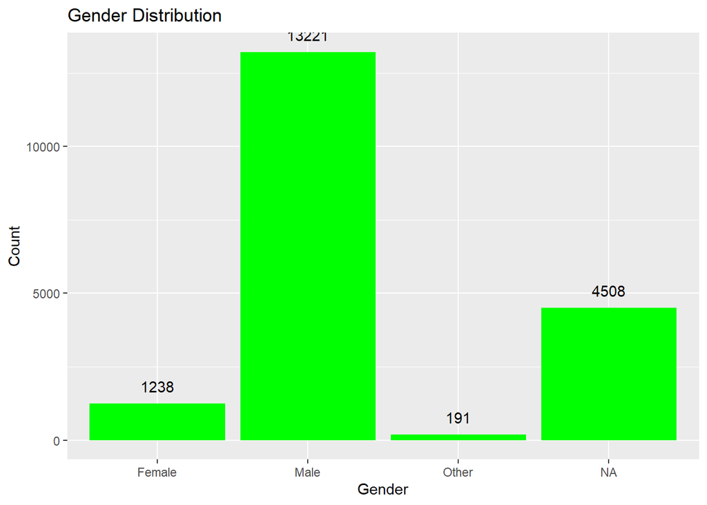

```r
ggplot(associate_sub_train_df,aes(x=gender))+
  geom_bar(fill = "green")+
  xlab("Gender")+
  ylab("Count")+
  geom_text(stat='count', aes(label=..count..), vjust=-1)+
  ggtitle("Gender Distribution")
```

```r
prop.table(table(associate_sub_train_df$gender))
```

```
##
##     Female       Male      Other
## 0.08450512 0.90245734 0.01303754
```

### Basis gender data is distributed as 90% males,8% fenmales and 1% others

### Analysing the distribution by experience in dataset

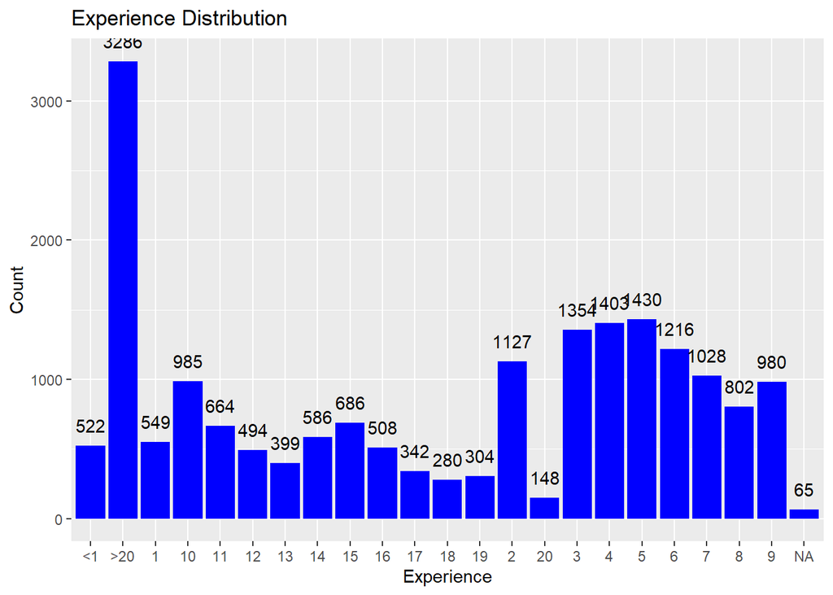

```r
ggplot(associate_sub_train_df,aes(x=experience))+
  geom_bar(fill = "blue")+
  xlab("Experience")+
  ylab("Count")+
  geom_text(stat='count', aes(label=..count..), vjust=-1)+
  ggtitle("Experience Distribution")
```

```r
prop.table(table(associate_sub_train_df$experience))
```

```
##
##          <1         >20           1          10          11          12
## 0.027339863 0.172104960 0.028753994 0.051589588 0.034777143 0.025873357
##          13          14          15          16          17          18
## 0.020897711 0.030691877 0.035929398 0.026606610 0.017912324 0.014665060
##          19           2          20           3           4           5
## 0.015922066 0.059026868 0.007751532 0.070916043 0.073482428 0.074896559
##           6           7           8           9
## 0.063688263 0.053841722 0.042004923 0.051327712
```

### Maximum number of employees (17%) has experience>20yrs

## Analysing Distribution by relevant experience

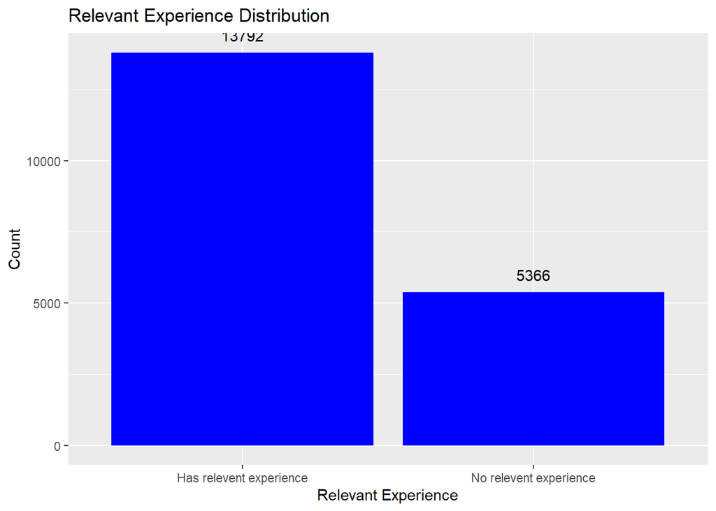

```r
ggplot(associate_sub_train_df,aes(x=relevent_experience))+
  geom_bar(fill = "blue")+
  xlab("Relevant Experience")+
  ylab("Count")+
  geom_text(stat='count', aes(label=..count..), vjust=-1)+
  ggtitle("Relevant Experience Distribution")
```

```r
prop.table(table(associate_sub_train_df$relevent_experience))
```

```
##
## Has relevent experience  No relevent experience
##               0.7199081               0.2800919
```

### 72% of the trainees have relevant experience and 28% have no relevant experience

### Analysing Distribution by enrolled university

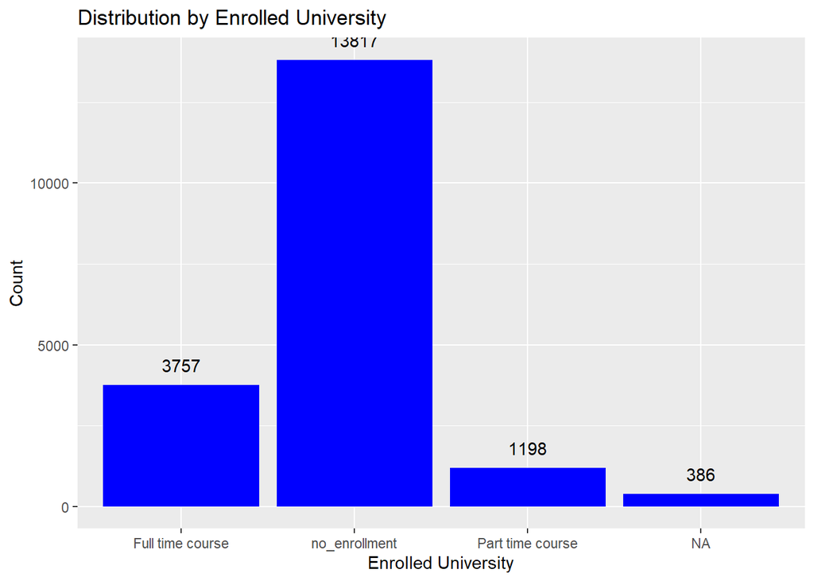

```r
ggplot(associate_sub_train_df,aes(x=enrolled_university))+
  geom_bar(fill = "blue")+
  xlab("Enrolled University")+
  ylab("Count")+
  geom_text(stat='count', aes(label=..count..), vjust=-1)+
  ggtitle("Distribution by Enrolled University")
```

```r
prop.table(table(associate_sub_train_df$enrolled_university))
```

```
##
## Full time course    no_enrollment Part time course
##       0.20013850       0.73604304       0.06381845
```

### 74% of the trainees are currently not enrolled in university, 20% are enrolled in a full time course and 6% in part time courses

### Analysing distribution by Education Level

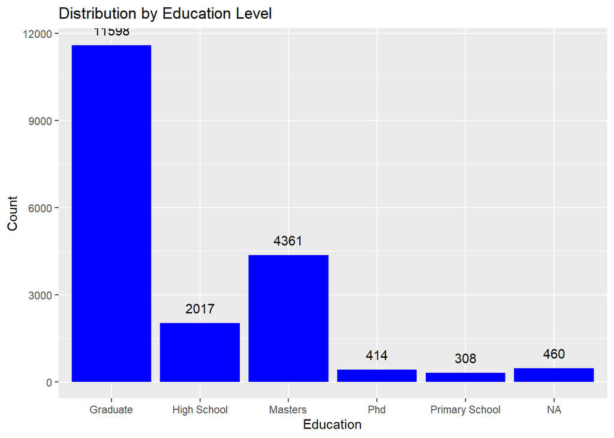

```r
ggplot(associate_sub_train_df,aes(x=education_level))+
  geom_bar(fill = "blue")+
  xlab("Education")+
  ylab("Count")+
  geom_text(stat='count', aes(label=..count..), vjust=-1)+
  ggtitle("Distribution by Education Level")
```

```r
prop.table(table(associate_sub_train_df$education_level))
```

```
##
##       Graduate    High School        Masters            Phd Primary School
##     0.62028024     0.10787250     0.23323350     0.02214141     0.01647235
```

## Graduates form the highest proportion (62%) of trainees who enroll for trainings followed by trainees with 23% holding Masters degree, 10% holding High School degree, 2% holding Phd degree and 1% holding primary school degree

### Analysing distribution by Major

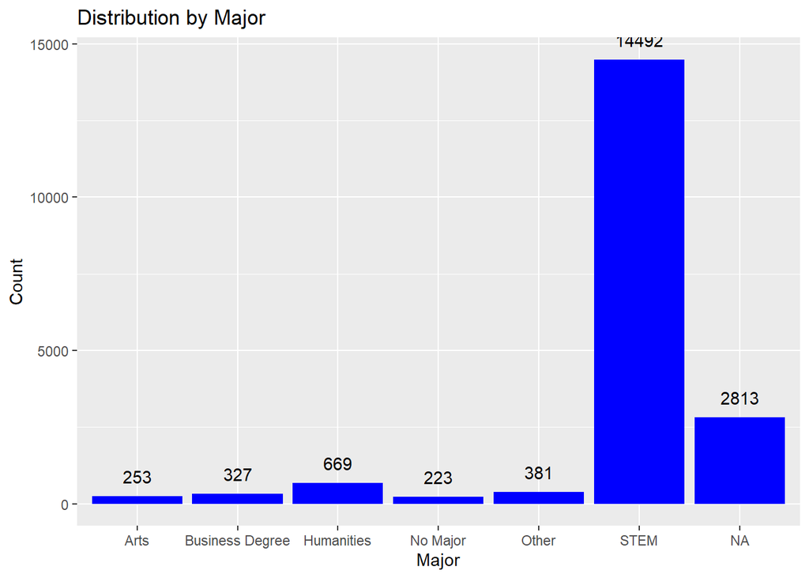

```r
ggplot(associate_sub_train_df,aes(x=major_discipline))+
  geom_bar(fill = "blue")+
  xlab("Major")+
  ylab("Count")+
  geom_text(stat='count', aes(label=..count..), vjust=-1)+
  ggtitle("Distribution by Major")
```

```r
prop.table(table(associate_sub_train_df$major_discipline))
```

```
##
##            Arts Business Degree      Humanities        No Major           Other
##      0.01547874      0.02000612      0.04092995      0.01364332      0.02330988
##            STEM
##      0.88663200
```

### Maximum trainees have majors in STEM (89%), followed by Humanities (4%), Business Degree and others (2%), Arts and no major (1%)

### Analysing distribution by Company Size

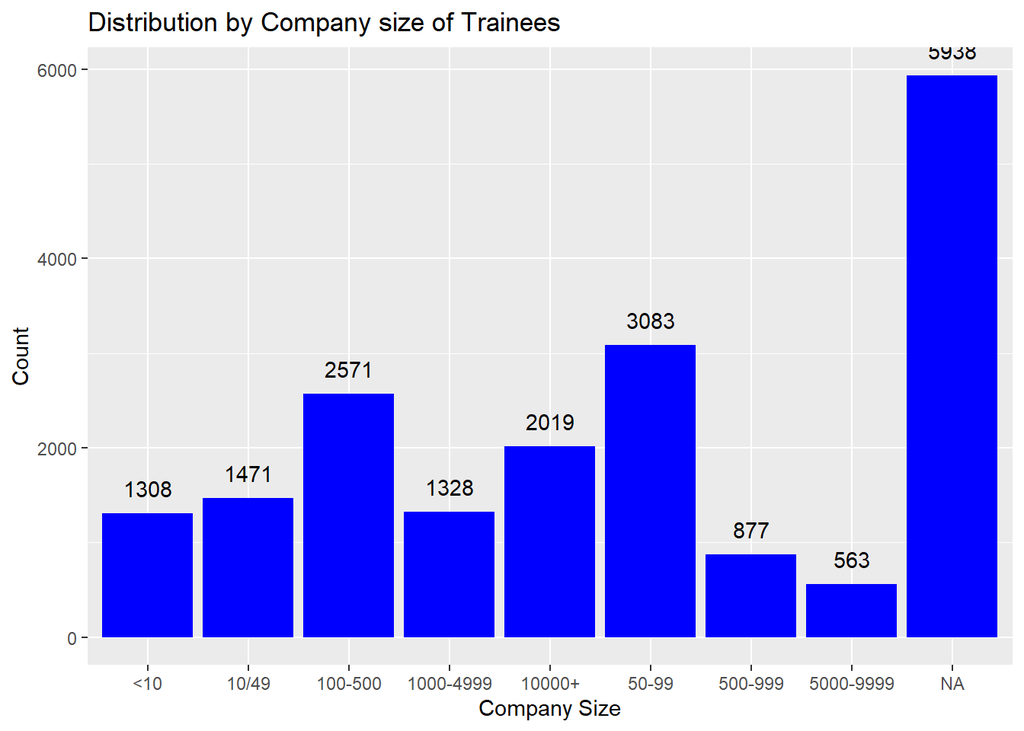

```r
ggplot(associate_sub_train_df,aes(x=company_size))+
  geom_bar(fill = "blue")+
  xlab("Company Size")+
  ylab("Count")+
  geom_text(stat='count', aes(label=..count..), vjust=-1)+
  ggtitle("Distribution by Company size of Trainees")
```

```r
prop.table(table(associate_sub_train_df$company_size))
```

```
##
##        <10      10/49    100-500  1000-4999     10000+      50-99    500-999
## 0.09894100 0.11127080 0.19447806 0.10045386 0.15272315 0.23320726 0.06633888
##  5000-9999
## 0.04258699
```

### Analysing distribution by Company Type

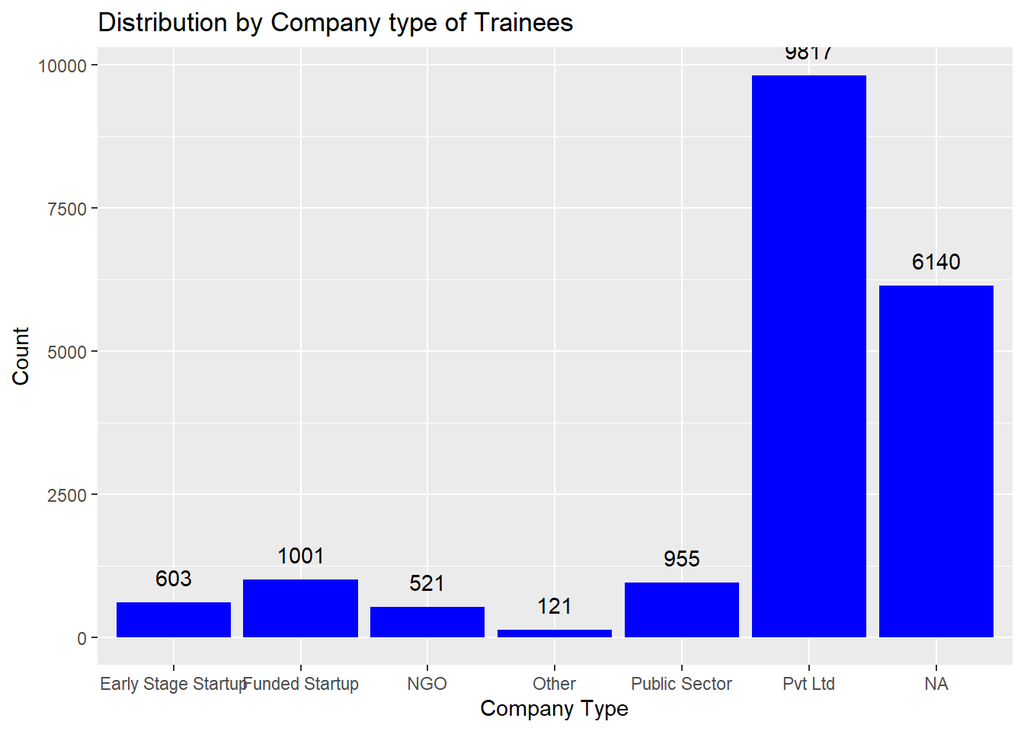

```r
ggplot(associate_sub_train_df,aes(x=company_type))+
  geom_bar(fill = "blue")+
  xlab("Company Type")+
  ylab("Count")+
  geom_text(stat='count', aes(label=..count..), vjust=-1)+
  ggtitle("Distribution by Company type of Trainees")
```

```r
prop.table(table(associate_sub_train_df$company_type))
```

```
##
## Early Stage Startup      Funded Startup                 NGO               Other
##         0.046320479         0.076893532         0.040021509         0.009294823
##       Public Sector             Pvt Ltd
##         0.073359963         0.754109694
```

### 75% of the trainees are from Pvt Ltd, 7% each from Public and Funded startup, 4% each from NGO and Early Stage Startup

### Analysing distribution by Last New Job

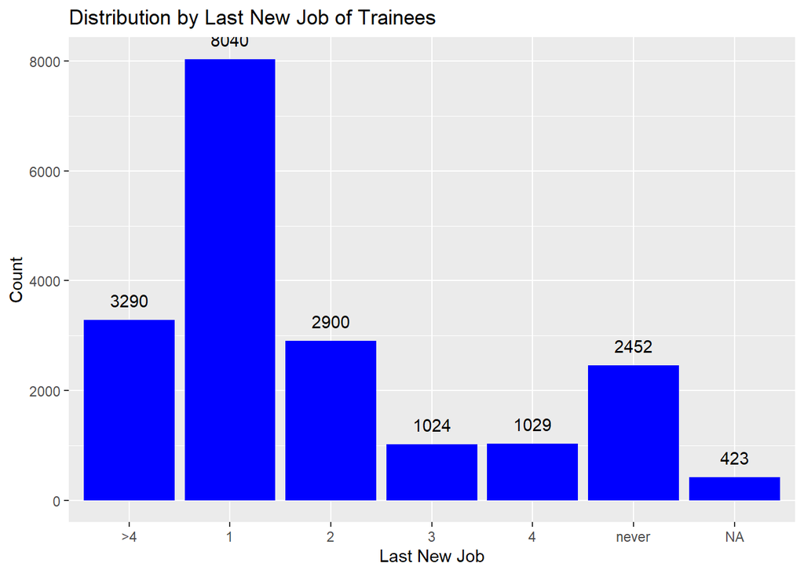

```r
ggplot(associate_sub_train_df,aes(x=last_new_job))+
  geom_bar(fill = "blue")+
  xlab("Last New Job")+
  ylab("Count")+
  geom_text(stat='count', aes(label=..count..), vjust=-1)+
  ggtitle("Distribution by Last New Job of Trainees")
```

```r
prop.table(table(associate_sub_train_df$last_new_job))
```

```
##
##         >4          1          2          3          4      never
## 0.17560715 0.42914331 0.15479050 0.05465706 0.05492394 0.13087804
```

## 43% of the trainees have changed job in last 1 year followed by 18% who have changes last job >4 years back and 13% who have never chnaged a job

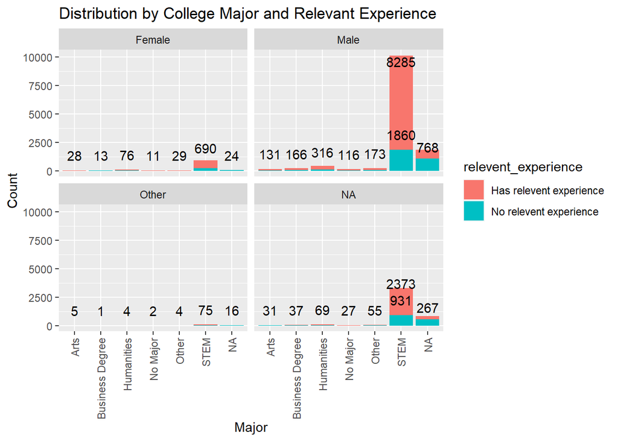

```r
ggplot(associate_sub_train_df,aes(x=major_discipline,fill=relevent_experience))+
  geom_bar()+
  facet_wrap("gender")+
  theme(axis.text.x = element_text(angle = 90, hjust =1, vjust = 0.5))+
  xlab("Major")+
  ylab("Count")+
  geom_text(stat='count', aes(label=..count..), vjust=-1,check_overlap = TRUE)+
  ggtitle("Distribution by College Major and Relevant Experience")
```

### Analysing distribution by City Development Index and Relevant Experience

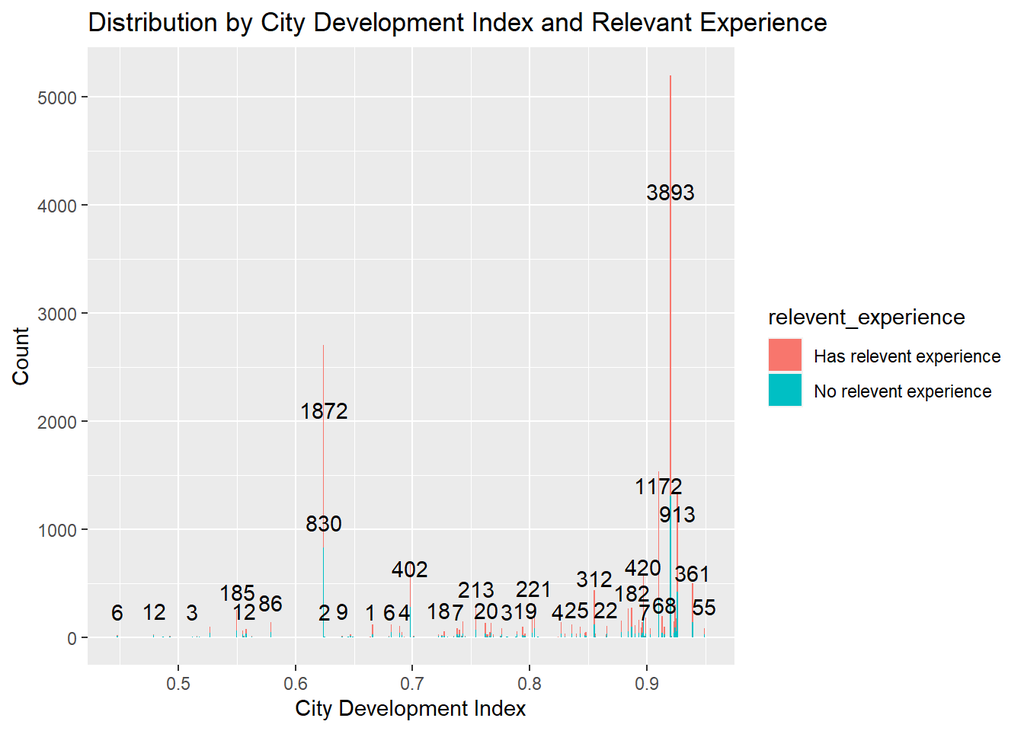

```r
ggplot(associate_sub_train_df,aes(x=city_development_index,fill=relevent_experience))+
  geom_bar()+
  xlab("City Development Index")+
  ylab("Count")+
  geom_text(stat='count', aes(label=..count..), vjust=-1,check_overlap = TRUE)+
  ggtitle("Distribution by City Development Index and Relevant Experience")
```

## More trainees have relevant experience in cities with high city development index

## Analysing the data with respect to target

## Target vs Gender

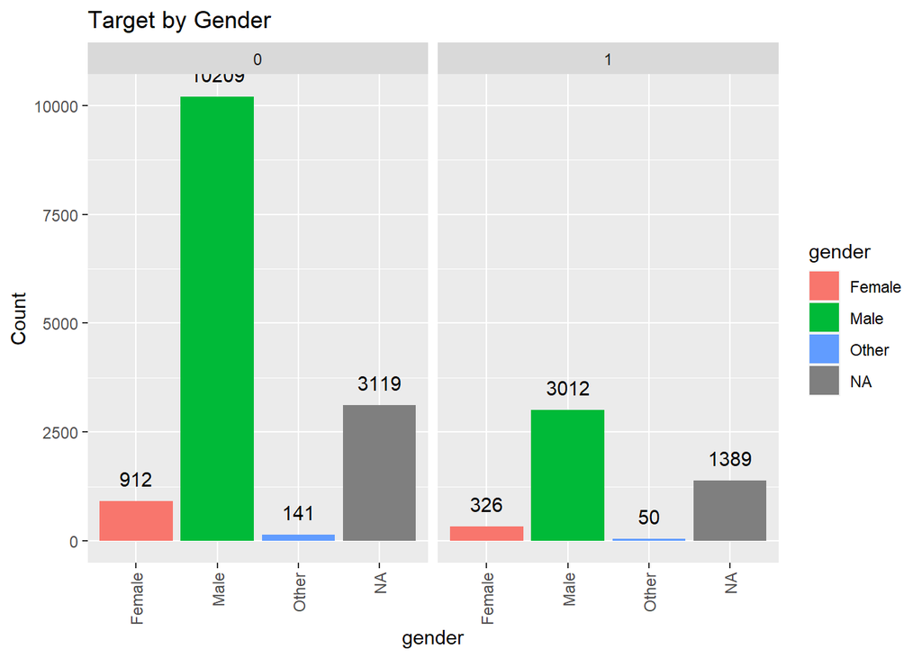

```r
ggplot(associate_sub_train_df,aes(x=gender,fill=gender))+
  geom_bar()+
  facet_wrap("target")+
  theme(axis.text.x = element_text(angle = 90, hjust =1, vjust = 0.5))+
  xlab("gender")+
  ylab("Count")+
  geom_text(stat='count', aes(label=..count..), vjust=-1,check_overlap = TRUE)+
  ggtitle("Target by Gender")
```

```r
prop.table(table(associate_sub_train_df$target,associate_sub_train_df$gender))
```

```
##
##          Female        Male       Other
##   0 0.062252560 0.696860068 0.009624573
##   1 0.022252560 0.205597270 0.003412969
```

### 20% of males and 2% females have been looking for a job change

## Target and Experience

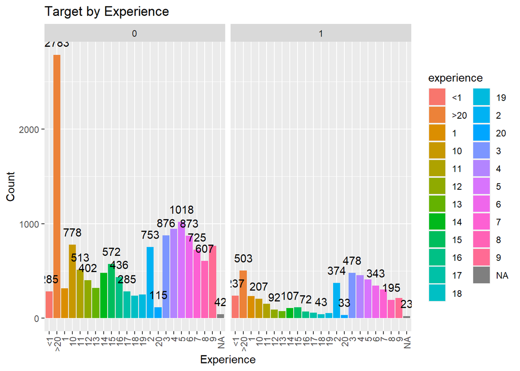

```r
ggplot(associate_sub_train_df,aes(x=experience,fill=experience))+
  geom_bar()+
  facet_wrap("target")+
  theme(axis.text.x = element_text(angle = 90, hjust =1, vjust = 0.5))+
  xlab("Experience")+
  ylab("Count")+
  geom_text(stat='count', aes(label=..count..), vjust=-1,check_overlap = TRUE)+
  ggtitle("Target by Experience")
```

```r
prop.table(table(associate_sub_train_df$target,associate_sub_train_df$experience))
```

```
##
##              <1         >20           1          10          11          12
##   0 0.014926937 0.145760226 0.016550568 0.040747918 0.026868486 0.021054837
##   1 0.012412926 0.026344734 0.012203425 0.010841670 0.007908658 0.004818520
##
##              13          14          15          16          17          18
##   0 0.016864820 0.025087728 0.029958624 0.022835594 0.014926937 0.012412926
##   1 0.004032892 0.005604148 0.005970775 0.003771016 0.002985387 0.002252134
##
##              19           2          20           3           4           5
##   0 0.013146179 0.039438538 0.006023150 0.045880689 0.049546954 0.053317970
##   1 0.002775886 0.019588331 0.001728382 0.025035353 0.023935474 0.021578589
##
##               6           7           8           9
##   0 0.045723564 0.037972032 0.031791756 0.040171791
##   1 0.017964699 0.015869690 0.010213167 0.011155921
```

### Target and Relevant Experience

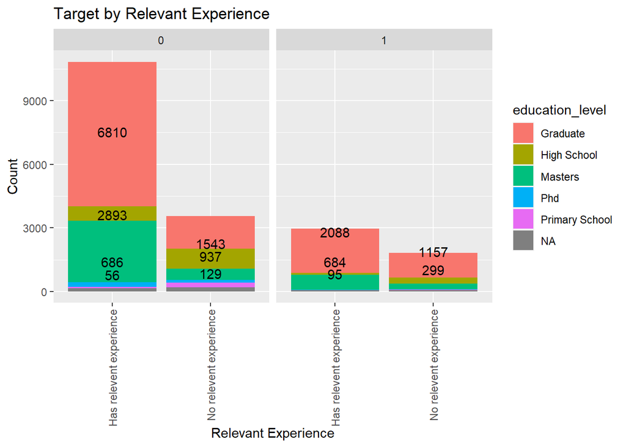

```r
ggplot(associate_sub_train_df,aes(x=relevent_experience,fill=education_level))+
  geom_bar()+
  facet_wrap("target")+
  theme(axis.text.x = element_text(angle = 90, hjust =1, vjust = 0.5))+
  xlab("Relevant Experience")+
  ylab("Count")+
  geom_text(stat='count', aes(label=..count..), vjust=-1,check_overlap = TRUE)+
  ggtitle("Target by Relevant Experience")
```

```r
prop.table(table(associate_sub_train_df$target,associate_sub_train_df$education_level,associate_sub_train_df$relevent_experience))
```

```
## , ,  = Has relevent experience
##
##
##         Graduate  High School      Masters          Phd Primary School
##   0 0.3642100759 0.0366884159 0.1547224302 0.0121403359   0.0029949727
##   1 0.1116696973 0.0050807573 0.0365814526 0.0017114130   0.0005348166
##
## , ,  = No relevent experience
##
##
##         Graduate  High School      Masters          Phd Primary School
##   0 0.0825221949 0.0501123115 0.0285057225 0.0068991336   0.0112846294
##   1 0.0618782758 0.0159910151 0.0134238956 0.0013905231   0.0016579313
```

```r
prop.table(table(associate_sub_train_df$target,associate_sub_train_df$relevent_experience))
```

```
##
##     Has relevent experience No relevent experience
##   0              0.56535129             0.18530118
##   1              0.15455684             0.09479069
```

### 11% of the graduates,3% of the trainees with masters degree who has relevant degree looking for job change, 16% of the trainees with STEM who has relevant experience looking for a job

### Target and Major, Relevant Experience

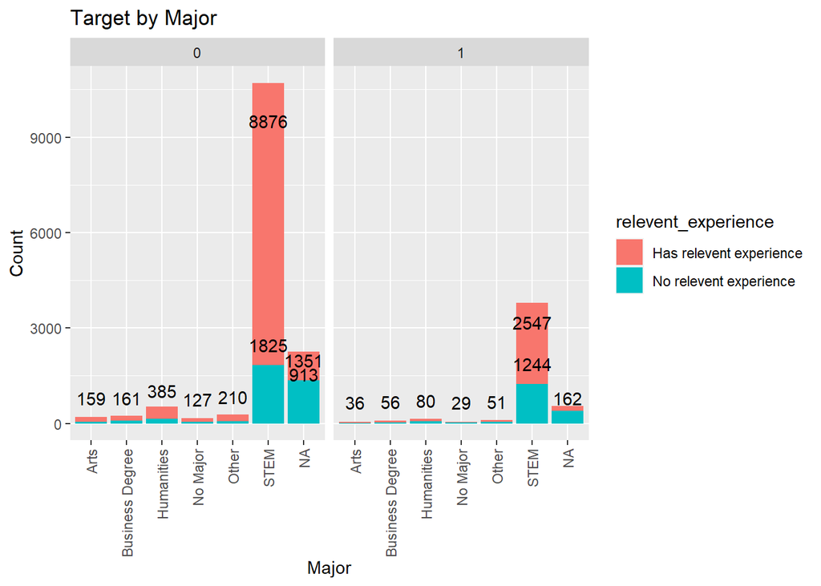

```r
ggplot(associate_sub_train_df,aes(x=major_discipline,fill=relevent_experience))+
  geom_bar()+
  facet_wrap("target")+
  theme(axis.text.x = element_text(angle = 90, hjust =1, vjust = 0.5))+
  xlab("Major")+
  ylab("Count")+
  geom_text(stat='count', aes(label=..count..), vjust=-1,check_overlap = TRUE)+
  ggtitle("Target by Major")
```

```r
prop.table(table(associate_sub_train_df$target,associate_sub_train_df$major_discipline,associate_sub_train_df$relevent_experience))
```

```
## , ,  = Has relevent experience
##
##
##            Arts Business Degree  Humanities    No Major       Other        STEM
##   0 0.009727745     0.009850107 0.023554604 0.007769960 0.012847966 0.543040685
##   1 0.002202508     0.003426124 0.004894463 0.001774243 0.003120220 0.155827470
##
## , ,  = No relevent experience
##
##
##            Arts Business Degree  Humanities    No Major       Other        STEM
##   0 0.002508412     0.004894463 0.008748853 0.002508412 0.004221474 0.111654940
##   1 0.001040073     0.001835424 0.003732028 0.001590701 0.003120220 0.076108902
```

```r
prop.table(table(associate_sub_train_df$target,associate_sub_train_df$major_discipline,associate_sub_train_df$education_level,associate_sub_train_df$relevent_experience))
```

```
## , ,  = Graduate,  = Has relevent experience
##
##
##             Arts Business Degree   Humanities     No Major        Other
##   0 8.259407e-03    7.464056e-03 1.517284e-02 6.546344e-03 8.626491e-03
##   1 1.468339e-03    2.753136e-03 3.609667e-03 1.529520e-03 2.691955e-03
##
##             STEM
##   0 3.700214e-01
##   1 1.155705e-01
##
## , ,  = High School,  = Has relevent experience
##
##
##             Arts Business Degree   Humanities     No Major        Other
##   0 0.000000e+00    0.000000e+00 0.000000e+00 0.000000e+00 0.000000e+00
##   1 0.000000e+00    0.000000e+00 0.000000e+00 0.000000e+00 0.000000e+00
##
##             STEM
##   0 0.000000e+00
##   1 0.000000e+00
##
## , ,  = Masters,  = Has relevent experience
##
##
##             Arts Business Degree   Humanities     No Major        Other
##   0 1.345977e-03    2.386051e-03 7.769960e-03 1.223616e-03 3.915571e-03
##   1 6.729887e-04    6.729887e-04 1.162435e-03 2.447232e-04 3.670847e-04
##
##             STEM
##   0 1.601713e-01
##   1 3.854390e-02
##
## , ,  = Phd,  = Has relevent experience
##
##
##             Arts Business Degree   Humanities     No Major        Other
##   0 1.223616e-04    0.000000e+00 6.118079e-04 0.000000e+00 3.059039e-04
##   1 6.118079e-05    0.000000e+00 1.223616e-04 0.000000e+00 6.118079e-05
##
```

[output cut: 54 more lines]

```
##
##             STEM
##   0 6.913429e-03
##   1 1.468339e-03
##
## , ,  = Primary School,  = No relevent experience
##
##
##             Arts Business Degree   Humanities     No Major        Other
##   0 0.000000e+00    0.000000e+00 0.000000e+00 0.000000e+00 0.000000e+00
##   1 0.000000e+00    0.000000e+00 0.000000e+00 0.000000e+00 0.000000e+00
##
##             STEM
##   0 0.000000e+00
##   1 0.000000e+00
```

### 11% of the graduates with STEM as major , having relevant experience looking for a job change

### Target and Last NEw job

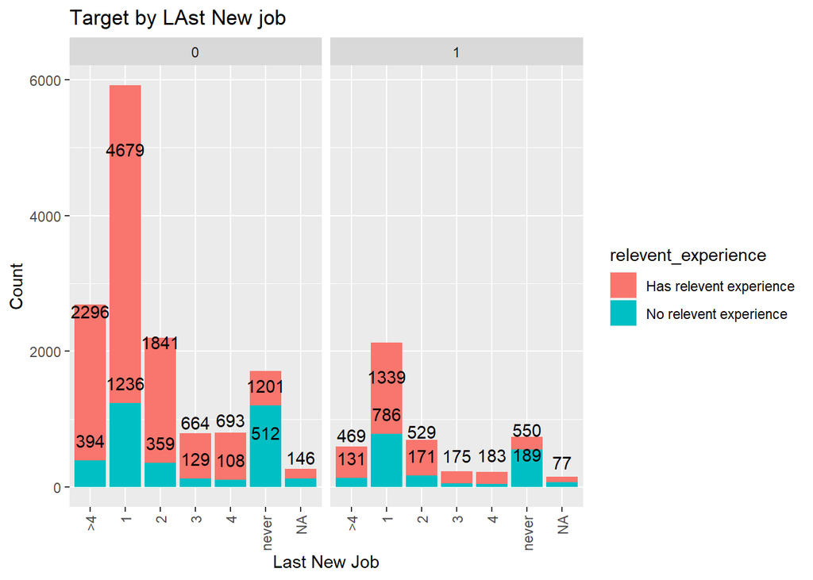

```r
ggplot(associate_sub_train_df,aes(x=last_new_job,fill=relevent_experience))+
  geom_bar()+
  facet_wrap("target")+
  theme(axis.text.x = element_text(angle = 90, hjust =1, vjust = 0.5))+
  xlab("Last New Job")+
  ylab("Count")+
  geom_text(stat='count', aes(label=..count..), vjust=-1,check_overlap = TRUE)+
  ggtitle("Target by LAst New job")
```

```r
prop.table(table(associate_sub_train_df$target,associate_sub_train_df$last_new_job,associate_sub_train_df$relevent_experience))
```

```
## , ,  = Has relevent experience
##
##
##              >4           1           2           3           4       never
##   0 0.122551374 0.249746464 0.098265279 0.035441687 0.036989592 0.027328529
##   1 0.025033360 0.071470510 0.028235922 0.009340806 0.009767814 0.010088070
##
## , ,  = No relevent experience
##
##
##              >4           1           2           3           4       never
##   0 0.021030157 0.065972778 0.019161996 0.006885508 0.005764612 0.064104617
##   1 0.006992260 0.041953563 0.009127302 0.002989058 0.002401922 0.029356819
```

### 7% of the trainees who has changed new job in last 1 year looking for a job change

## DATA PREPROCESSING

### Data Cleaning - replacing “never” and “>4” in last new job with ’0” and “5”

```r
associate_sub_test_df <-associate_sub_test_df %>% mutate(last_new_job = ifelse(last_new_job == "never", 0, last_new_job ))
associate_sub_test_df <-associate_sub_test_df %>% mutate(last_new_job = ifelse(last_new_job == ">4", 5, last_new_job ))

associate_sub_train_df <-associate_sub_train_df %>% mutate(last_new_job = ifelse(last_new_job == "never", 0, last_new_job ))
associate_sub_train_df <-associate_sub_train_df %>% mutate(last_new_job = ifelse(last_new_job == ">4", 5, last_new_job ))
```

### Data cleaning - replacing “>20 and <1” in experience to “21 and 0.5”

```r
associate_sub_test_df <-associate_sub_test_df %>% mutate(experience = ifelse(experience == "<1", 0.5, experience ))
associate_sub_test_df <-associate_sub_test_df %>% mutate(experience = ifelse(experience == ">20", 21, experience ))

associate_sub_train_df <-associate_sub_train_df %>% mutate(experience = ifelse(experience == "<1", 0.5, experience ))
associate_sub_train_df <-associate_sub_train_df %>% mutate(experience = ifelse(experience == ">20", 21, experience ))
```

### Data Cleaning - Replacing “10/49” in company size to “10-49”

```r
associate_sub_test_df <-associate_sub_test_df %>% mutate(company_size = ifelse(company_size == "10/49", "10-49", company_size ))
associate_sub_train_df <-associate_sub_train_df %>% mutate(company_size = ifelse(company_size == "10/49", "10-49", company_size ))
```

## Converting datatypes of variables in test and train dataset

```r
associate_sub_test_df$experience <- as.numeric(associate_sub_test_df$experience)
associate_sub_test_df$last_new_job<- as.numeric(associate_sub_test_df$last_new_job)
associate_sub_test_df$gender <- as.factor(associate_sub_test_df$gender)
associate_sub_test_df$relevent_experience <- as.factor(associate_sub_test_df$relevent_experience)
associate_sub_test_df$enrolled_university <- as.factor(associate_sub_test_df$enrolled_university)
associate_sub_test_df$major_discipline  <- as.factor(associate_sub_test_df$major_discipline )
associate_sub_test_df$company_type  <- as.factor(associate_sub_test_df$company_type )
associate_sub_test_df$company_size  <- as.factor(associate_sub_test_df$company_size )
associate_sub_test_df$education_level <- factor(associate_sub_test_df$education_level, ordered = TRUE,
                                              levels = c("Phd", "Masters", "Graduate", "High School", "Primary School"))

associate_sub_train_df$experience <- as.numeric(associate_sub_train_df$experience)
associate_sub_train_df$last_new_job<- as.numeric(associate_sub_train_df$last_new_job)
associate_sub_train_df$gender <- as.factor(associate_sub_train_df$gender)
associate_sub_train_df$relevent_experience <- as.factor(associate_sub_train_df$relevent_experience)
associate_sub_train_df$enrolled_university <- as.factor(associate_sub_train_df$enrolled_university)
associate_sub_train_df$major_discipline  <- as.factor(associate_sub_train_df$major_discipline )
associate_sub_train_df$company_type  <- as.factor(associate_sub_train_df$company_type )
associate_sub_train_df$company_size  <- as.factor(associate_sub_train_df$company_size )
associate_sub_train_df$education_level <- factor(associate_sub_train_df$education_level, ordered = TRUE,
                                              levels = c("Phd", "Masters", "Graduate", "High School", "Primary School"))
associate_sub_train_df$target  <- as.factor(associate_sub_train_df$target)
```

### Checking for proportion of missing values in Train and Test data

```r
table(is.na(associate_sub_train_df))
```

```
##
##  FALSE   TRUE
## 209163  20733
```

```r
table(is.na(associate_sub_test_df))
```

```
##
## FALSE  TRUE
## 21215  2204
```

```r
table(is.na(associate_sub_train_df$last_new_job))
```

```
##
## FALSE  TRUE
## 18735   423
```

```r
str(associate_sub_train_df)
```

```
## 'data.frame':    19158 obs. of  12 variables:
##  $ city_development_index: num  0.92 0.776 0.624 0.789 0.767 0.764 0.92 0.762 0.92 0.92 ...
##  $ gender                : Factor w/ 3 levels "Female","Male",..: 2 2 NA NA 2 NA 2 2 2 NA ...
##  $ relevent_experience   : Factor w/ 2 levels "Has relevent experience",..: 1 2 2 2 1 1 1 1 1 1 ...
##  $ enrolled_university   : Factor w/ 3 levels "Full time course",..: 2 2 1 NA 2 3 2 2 2 2 ...
##  $ education_level       : Ord.factor w/ 5 levels "Phd"<"Masters"<..: 3 3 3 3 2 3 4 3 3 3 ...
##  $ major_discipline      : Factor w/ 6 levels "Arts","Business Degree",..: 6 6 6 2 6 6 NA 6 6 6 ...
##  $ experience            : num  21 15 5 0.5 21 11 5 13 7 17 ...
##  $ company_size          : Factor w/ 8 levels "<10","10-49",..: NA 6 NA NA 6 NA 6 1 6 5 ...
##  $ company_type          : Factor w/ 6 levels "Early Stage Startup",..: NA 6 NA 6 2 NA 2 6 6 6 ...
##  $ last_new_job          : num  1 5 0 0 4 1 1 5 1 5 ...
##  $ training_hours        : int  36 47 83 52 8 24 24 18 46 123 ...
##  $ target                : Factor w/ 2 levels "0","1": 2 1 1 2 1 2 1 2 2 1 ...
```

```r
str(associate_sub_test_df)
```

```
## 'data.frame':    2129 obs. of  11 variables:
##  $ city_development_index: num  0.827 0.92 0.624 0.827 0.92 0.899 0.624 0.92 0.878 0.624 ...
##  $ gender                : Factor w/ 3 levels "Female","Male",..: 2 1 2 2 2 2 NA 1 2 2 ...
##  $ relevent_experience   : Factor w/ 2 levels "Has relevent experience",..: 1 1 2 1 1 2 1 1 1 1 ...
##  $ enrolled_university   : Factor w/ 3 levels "Full time course",..: 1 2 2 2 2 3 2 2 2 1 ...
##  $ education_level       : Ord.factor w/ 5 levels "Phd"<"Masters"<..: 3 3 4 2 3 2 3 3 3 3 ...
##  $ major_discipline      : Factor w/ 6 levels "Arts","Business Degree",..: 6 6 NA 6 6 6 6 6 6 NA ...
##  $ experience            : num  9 5 0.5 11 21 10 0.5 21 14 3 ...
##  $ company_size          : Factor w/ 8 levels "<10","10-49",..: 1 NA NA 2 5 NA 3 NA NA 6 ...
##  $ company_type          : Factor w/ 6 levels "Early Stage Startup",..: NA 6 6 6 6 NA 6 NA NA 2 ...
##  $ last_new_job          : num  1 1 0 1 5 2 1 5 4 1 ...
##  $ training_hours        : int  21 98 15 39 72 12 11 81 2 4 ...
```

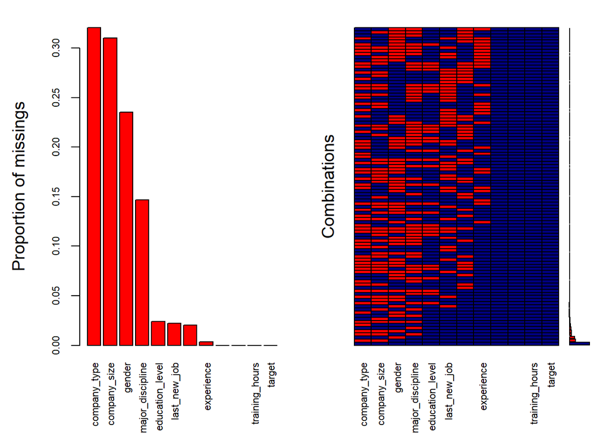

```
##
##  Variables sorted by number of missings:
##                Variable       Count
##            company_type 0.320492745
##            company_size 0.309948846
##                  gender 0.235306399
##        major_discipline 0.146831611
##         education_level 0.024010857
##            last_new_job 0.022079549
##     enrolled_university 0.020148241
##              experience 0.003392839
##  city_development_index 0.000000000
##     relevent_experience 0.000000000
##          training_hours 0.000000000
##                  target 0.000000000
```

```r
missing_data_plot_train <- aggr(associate_sub_train_df, col=c('navyblue','red'), numbers=TRUE, sortVars=TRUE,axes=TRUE,cex.lab=1.2,cex.axis=.7)
```

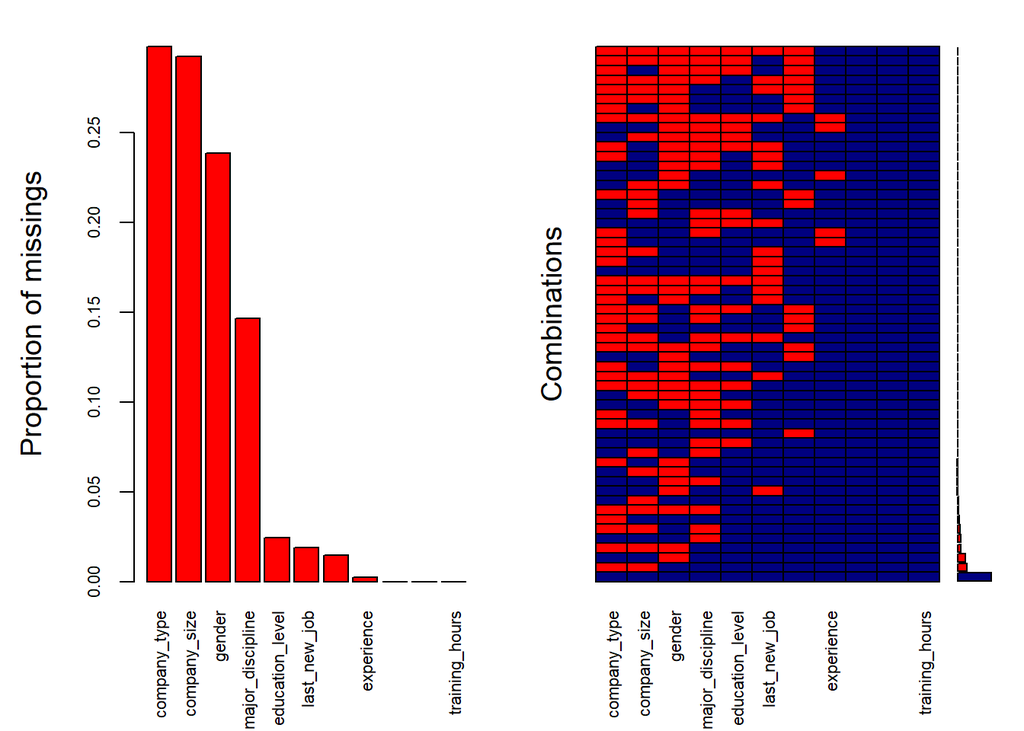

```
##
##  Variables sorted by number of missings:
##                Variable      Count
##            company_type 0.29779239
##            company_size 0.29215594
##                  gender 0.23860968
##        major_discipline 0.14654767
##         education_level 0.02442461
##            last_new_job 0.01878816
##     enrolled_university 0.01456083
##              experience 0.00234852
##  city_development_index 0.00000000
##     relevent_experience 0.00000000
##          training_hours 0.00000000
```

```r
missing_data_plot_test <- aggr(associate_sub_test_df, col=c('navyblue','red'), numbers=TRUE, sortVars=TRUE,axes=TRUE,cex.lab=1.2,cex.axis=.7)
```

### Replacing the NA in Last New Job column with column mean

```r
associate_sub_train_df$last_new_job[is.na(associate_sub_train_df$last_new_job)] <- mean(associate_sub_train_df$last_new_job, na.rm = TRUE)
associate_sub_test_df$last_new_job[is.na(associate_sub_test_df$last_new_job)] <- mean(associate_sub_test_df$last_new_job, na.rm = TRUE)
```

### Using mode imputation for missing categorical values

```r
associate_sub_mode_traindf <- associate_sub_train_df
associate_sub_mode_testdf <- associate_sub_test_df

val <- unique(associate_sub_mode_traindf$company_type[!is.na(associate_sub_mode_traindf$company_type)])                   # Values in vec_miss
my_mode <- val[which.max(tabulate(match(associate_sub_mode_traindf$company_type, val)))]
associate_sub_mode_traindf$company_type_imp <- associate_sub_mode_traindf$company_type                                    # Replicate vec_miss
associate_sub_mode_traindf$company_type_imp[is.na(associate_sub_mode_traindf$company_type_imp)] <- my_mode                     # Impute by mode
```

```r
missingness <- c(rep("No Missings", 6), rep("Post Imputation", 6)) # Pre/post imputation
Category <- as.factor(rep(names(table(associate_sub_mode_traindf$company_type))))                   # Categories
Count <- c(as.numeric(table(table(associate_sub_mode_traindf$company_type))), as.numeric(table(associate_sub_mode_traindf$company_type_imp)))

data_barplot <- data.frame(missingness, Category, Count)
```

### Partitioning the train dataset into train and validation

```r
inTrain <- createDataPartition(y=associate_sub_train_df$target, p=0.6, list=FALSE)
train_df_train <- associate_sub_train_df[inTrain, ]
train_df_validate <- associate_sub_train_df[-inTrain, ]
dim(train_df_train)
```

```
## [1] 11496    12
```

```r
dim(train_df_validate)
```

```
## [1] 7662   12
```

### Checking MICE imputation for missing values. The MICE algorithm can impute mixes of continuous, binary, unordered categorical and ordered categorical data.

### Finding missing data pattern with MICE package

[figure not shown]

```
##      city_development_index relevent_experience last_new_job training_hours
## 8977                      1                   1            1              1
## 465                       1                   1            1              1
## 287                       1                   1            1              1
## 2798                      1                   1            1              1
## 2339                      1                   1            1              1
## 185                       1                   1            1              1
## 105                       1                   1            1              1
## 914                       1                   1            1              1
## 661                       1                   1            1              1
## 53                        1                   1            1              1
## 115                       1                   1            1              1
## 856                       1                   1            1              1
## 191                       1                   1            1              1
## 19                        1                   1            1              1
```

[output cut: 186 more lines]

```r
md.pattern(associate_sub_train_df)
```

```r
pMiss <- function(x){sum(is.na(x))/length(x)*100}
apply(train_df_train,2,pMiss)
```

```
## city_development_index                 gender    relevent_experience
##              0.0000000             23.5125261              0.0000000
##    enrolled_university        education_level       major_discipline
##              2.1659708              2.3747390             14.4398051
##             experience           company_size           company_type
##              0.3218511             31.1673626             32.2459986
##           last_new_job         training_hours                 target
##              0.0000000              0.0000000              0.0000000
```

```r
apply(train_df_validate,2,pMiss)
```

```
## city_development_index                 gender    relevent_experience
##              0.0000000             23.5578178              0.0000000
##    enrolled_university        education_level       major_discipline
##              1.7880449              2.4406160             15.0482903
##             experience           company_size           company_type
##              0.3654398             30.7361002             31.7541112
##           last_new_job         training_hours                 target
##              0.0000000              0.0000000              0.0000000
```

```r
str(associate_sub_train_df)
```

```
## 'data.frame':    19158 obs. of  12 variables:
##  $ city_development_index: num  0.92 0.776 0.624 0.789 0.767 0.764 0.92 0.762 0.92 0.92 ...
##  $ gender                : Factor w/ 3 levels "Female","Male",..: 2 2 NA NA 2 NA 2 2 2 NA ...
##  $ relevent_experience   : Factor w/ 2 levels "Has relevent experience",..: 1 2 2 2 1 1 1 1 1 1 ...
##  $ enrolled_university   : Factor w/ 3 levels "Full time course",..: 2 2 1 NA 2 3 2 2 2 2 ...
##  $ education_level       : Ord.factor w/ 5 levels "Phd"<"Masters"<..: 3 3 3 3 2 3 4 3 3 3 ...
##  $ major_discipline      : Factor w/ 6 levels "Arts","Business Degree",..: 6 6 6 2 6 6 NA 6 6 6 ...
##  $ experience            : num  21 15 5 0.5 21 11 5 13 7 17 ...
##  $ company_size          : Factor w/ 8 levels "<10","10-49",..: NA 6 NA NA 6 NA 6 1 6 5 ...
##  $ company_type          : Factor w/ 6 levels "Early Stage Startup",..: NA 6 NA 6 2 NA 2 6 6 6 ...
##  $ last_new_job          : num  1 5 0 0 4 1 1 5 1 5 ...
##  $ training_hours        : int  36 47 83 52 8 24 24 18 46 123 ...
##  $ target                : Factor w/ 2 levels "0","1": 2 1 1 2 1 2 1 2 2 1 ...
```

### 32% of data missing in company_type, 30% in company_size, 23% in gender, 14% in major_discipline, 2% each in education level and enrolled_university

### Imputing with MICE train,validate and test dataset

```r
train_df_train_impute <- mice(train_df_train, m=5, seed = 123)
train_df_validate_impute <- mice(train_df_validate,m=5,seed=123)
test_df_impute <- mice(associate_sub_test_df,m=5,seed=123)
Final_train_impute <- complete(train_df_train_impute)
Final_validate_impute <- complete(train_df_validate_impute)
Final_test_impute <- complete(test_df_impute)
```

### Cross validation using 10 fold

```r
trcontrol <- trainControl(method="cv",number =10)
metric <- "Accuracy"
```

## MODEL BUILDING

### 1) Linear Discriminant Analysis

```r
set.seed(10)
fit_lda <- train(target~., data=Final_train_impute, method="lda", metric=metric, trControl=trcontrol)
```

### 2) Logistic Regression

```r
set.seed(10)
fit_glm <- train(target~., data=Final_train_impute, method="glm", family="binomial",metric=metric, trControl=trcontrol)
```

### 3) Recursive Partioning and Regression Trees

```r
set.seed(10)
fit_rpart <- train(target~., data=Final_train_impute, method="rpart", metric=metric, trControl=trcontrol)
```

### 4) kNN

```r
set.seed(10)
fit_knn <- train(target~., data=Final_train_impute, method="knn", metric=metric, trControl=trcontrol)
```

### 5) Random Forest

```r
set.seed(10)
fit_rf <- train(target~., data=Final_train_impute, method="rf", metric=metric, trControl=trcontrol)
```

### Comparing accuracy of models

```r
results <- resamples(list(lda=fit_lda, GLM = fit_glm, DT=fit_rpart, knn=fit_knn))
summary(results)
```

```
##
## Call:
## summary.resamples(object = results)
##
## Models: lda, GLM, DT, knn
## Number of resamples: 10
##
## Accuracy
##          Min.   1st Qu.    Median      Mean   3rd Qu.      Max. NA's
## lda 0.7556522 0.7678919 0.7726087 0.7730526 0.7782855 0.7956522    0
## GLM 0.7582609 0.7630435 0.7680592 0.7697457 0.7761596 0.7843478    0
## DT  0.7615318 0.7732609 0.7786007 0.7786192 0.7870354 0.7921739    0
## knn 0.7260870 0.7397826 0.7433670 0.7422594 0.7450000 0.7519582    0
##
## Kappa
##          Min.    1st Qu.    Median      Mean   3rd Qu.      Max. NA's
## lda 0.2569249 0.28789026 0.3028121 0.3003864 0.3109423 0.3492625    0
## GLM 0.1882539 0.24297315 0.2571197 0.2533267 0.2735366 0.3030236    0
## DT  0.2946214 0.31774544 0.3335773 0.3319241 0.3440419 0.3702243    0
## knn 0.0848891 0.09144358 0.1026282 0.1070449 0.1192486 0.1459566    0
```

## INSIGHT - Recursive Partioning and Regression Trees shows the best mean accuracy of 78%

```r
print(fit_rpart)
```

```
## CART
##
## 11496 samples
##    11 predictor
##     2 classes: '0', '1'
##
## No pre-processing
## Resampling: Cross-Validated (10 fold)
## Summary of sample sizes: 10346, 10346, 10346, 10346, 10346, 10347, ...
## Resampling results across tuning parameters:
##
##   cp           Accuracy   Kappa
##   0.001046390  0.7753132  0.3157100
##   0.001185909  0.7786192  0.3319241
##   0.130449948  0.7643518  0.2025592
##
## Accuracy was used to select the optimal model using the largest value.
## The final value used for the model was cp = 0.001185909.
```

### Make predictions on the validate dataset using Recursive Partioning and Regression Trees Model

```r
prediction_trainee_model <- predict(fit_rpart, Final_validate_impute, na.action = na.pass)
confusionMatrix(prediction_trainee_model, Final_validate_impute$target)
```

```
## Confusion Matrix and Statistics
##
##           Reference
## Prediction    0    1
##          0 5184 1109
##          1  568  801
##
##                Accuracy : 0.7811
##                  95% CI : (0.7717, 0.7903)
##     No Information Rate : 0.7507
##     P-Value [Acc > NIR] : 2.383e-10
##
##                   Kappa : 0.3541
##
##  Mcnemar's Test P-Value : < 2.2e-16
##
##             Sensitivity : 0.9013
##             Specificity : 0.4194
##          Pos Pred Value : 0.8238
##          Neg Pred Value : 0.5851
##              Prevalence : 0.7507
##          Detection Rate : 0.6766
##    Detection Prevalence : 0.8213
##       Balanced Accuracy : 0.6603
##
##        'Positive' Class : 0
##
```

### Predicting on testing dataset using Recursive Partioning and Regression Trees Model

```r
prediction_testdf <- predict(fit_rpart, Final_test_impute, type = "raw")
Final_test_impute <- Final_test_impute %>% select(everything()) %>% mutate(target = prediction_testdf)
summary(prediction_testdf)
```

```
##    0    1
## 1728  401
```

### Writing the predicted output in csv file

```r
write.csv(Final_test_impute,"DSJobChange_finaloutput.csv")
```